# Non-reproductive dispersal drives migratory range dynamics and connectivity

Supplementary Material

Stephen H. Vickers, Aldina M.A. Franco, & James J. Gilroy

02 November 2022

## Setup

### Loading packages

```r
# loading packages devtools::install_github('thomasp85/patchwork')
pacman::p_load(raster, geosphere, ade4, data.table, tidyr, sna, cowplot, ggplot2,
    dplyr, plyr, biscale, formatR, pander, rnaturalearth, ggrepel, rgeos, ggpubr,
    kableExtra, scico)
options(scipen = 99999999)
```

## SM1: Supplementary Methods

### Creation of starting population

Distinct breeding and non-breeding ranges were defined within co-ordinate ranges of 0 and 1 on the longitudinal axis and 0.66–1 and 0–0.33 for the latitudinal axis (breeding and non-breeding respectively).

```r
# Set up the environment space:

brd_latrange <- c(1.333, 2)
brd_lonrange <- c(0, 1)
win_latrange <- c(0, 0.666)
win_lonrange <- c(0, 1)
```

Within the breeding range 10,000 individuals were placed with a uniform distribution and a sex ratio of 50/50.

```r
n <- 10000  # set a Total population size

starting_brd_locs <- data.frame(x = runif(n, brd_lonrange[1], brd_lonrange[2]), y = runif(n,
    brd_latrange[1], brd_latrange[2]))

starting_brd_locs$individual <- rownames(starting_brd_locs)

starting_brd_locs$Sex <- c("Female", "Male")

starting_brd_locs$season <- "brd"
```

Each individual was then given a southerly movement equal to the distance between breeding and non-breeding range centroids so to replicate the breeding population distribution on the non-breeding zone. This population was then used as the starting population of all burn-in replicates and has a ‘perfect’ connectivity score (Mantel correlation) of 1.0 as there is zero population mixing.

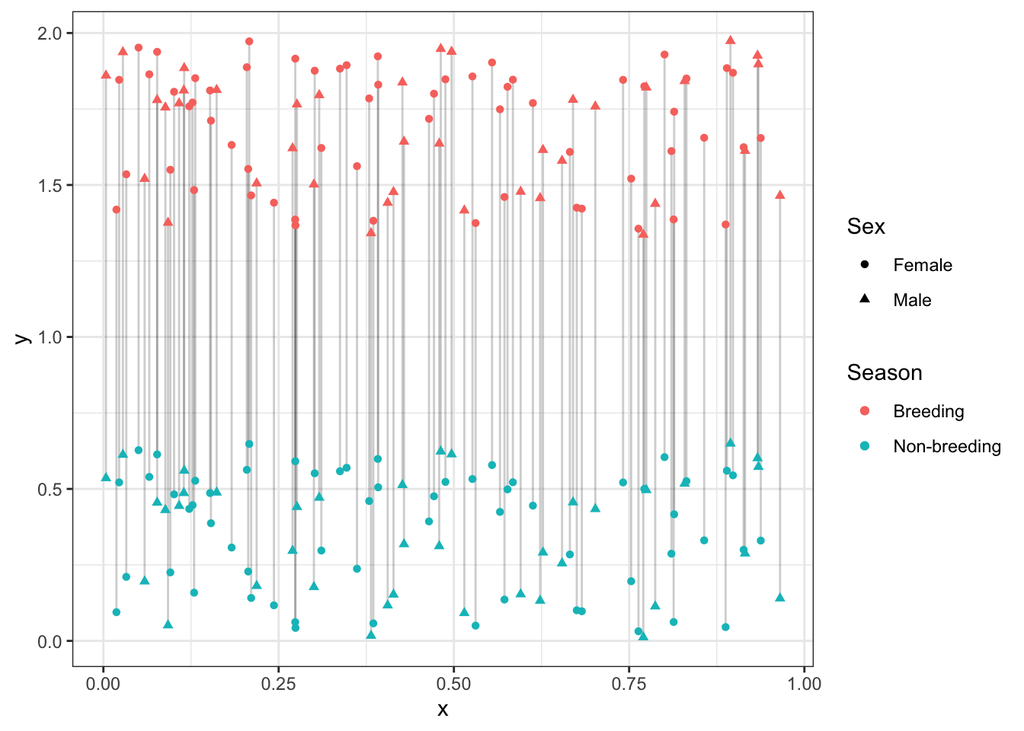

```r
midbrd <- c(mean(brd_lonrange), mean(brd_latrange))  # Midpoint of breeding

midwin <- c(mean(win_lonrange), mean(win_latrange))  # Midpoint of non-breeding

mid_dist <- distm(midbrd, midwin)

win_start <- destPointRhumb(starting_brd_locs[1:2], b = 180, d = mid_dist)  # Uniform southerly movement

starting_win_locs <- as.data.frame(win_start)

starting_win_locs$season <- "win"

names(starting_win_locs)[1:2] <- c("x", "y")

# write.csv(starting_brd_locs, file='burnin_start_brd.csv', row.names = F)
# write.csv(starting_win_locs, file='burnin_start_win.csv', row.names = F)
```

**Figure SM1a:** Example starting population for a subsample of 100 individuals (usually 10,000). An individuals breeding and non-breeding location is linked by a line.

### The 500-year burn-in

Within the burn-in phase there are nine customisable parameters, five of which were fixed in our simulations and four that were varied across three distinct levels:

- Simulation length (in years) – fixed at 500.
- Individuals sampled (for Mantel correlation) – fixed at 100 .
- Carrying capacity – fixed at 10,000 (initial population size).
- Density dependent breeding – fixed equation, see below.
- Density dependent survival in the non-breeding ground – fixed at 25 surviving individuals per grid cell (20x20 grid, 10,000 individuals total carrying capacity).
- Mutation rate (for gene encoding migratory distance & direction, where rate is the proportion of population that mutates each generation) – 0.01, 0.1, and 0.5.
- Mutation size (modifier for rgamma distance kernel that modifies inherited distance & direction) – 0.5, 1.5, and 3.
- Natal dispersal (shape parameter for rgamma distance kernel) – 0.5, 1.5, and 3.
- Migratory accuracy (ability to follow inherited migratory programme, controlled through shape parameter for rgamma distance kernel) – 0.5, 1.5, and 3.

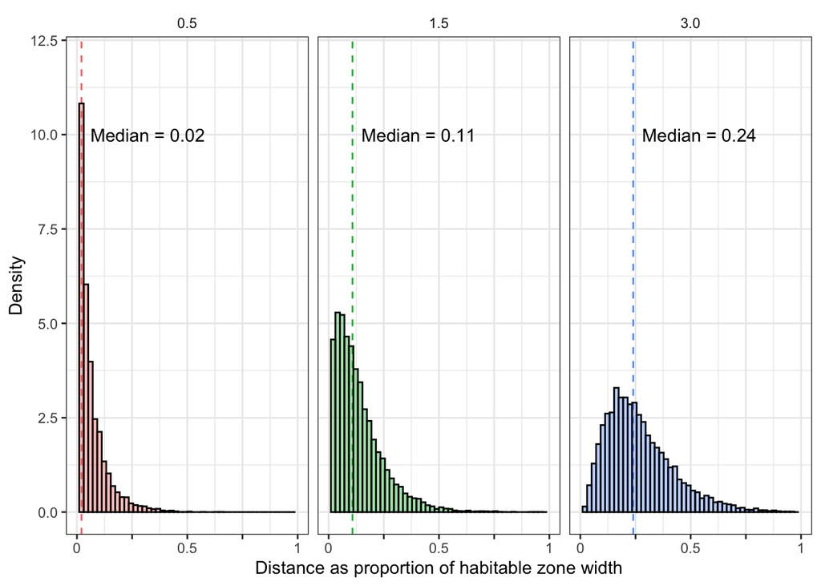

**Figure SM1b:** Density histograms of dispersal distances (as a proportion of the habitable zone width) produced through the function `rgamma()` with a sample size of 10,000, rate parameter of 0.0001, and shape parameters of either 0.5, 1.5, or 3.0 referred to as ‘Low’, ‘Medium’, and ‘High’ dispersal scenarios respectively in the manuscript. Distance of natal reproductive and natal non-reproductive dispersal for an individual was drawn from such distributions by random sampling. For natal reproductive dispersal, realised distances were drawn directly from a single kernel. For natal non-reproductive dispersal, realised dispersal distances were a product of sampling a kernel once for migratory accuracy related dispersal and sampling a (potentially different) kernel again if a mutation in the inherited migratory programme occurs.

#### Density dependent breeding

A 20x20 cell grid is drawn over the breeding range and a count of individuals within each grid cell is taken. Within each cell a breeding modifier is calculated as the cell carrying capacity (carrying capacity of the breeding range divided by the number of grid cells) divided by the abundance of individuals within the cell. The value is then capped at 5, such that each female within the population is limited to 10 offspring per generation. Each female within the grid cell is then matched with a random male in that grid cell, each female will pair once per year, but males may pair with multiple females. Number of offspring is then calculated as `breeding modifier*2`, if this value is less than 2 then the number of offspring will be fixed at either 1 or 2 based upon `if(sample(seq(100,200),1) < round(brd_mod*2, 2)*100){offspring=2}else{offspring=1}`.

Each female thus always has at least 1 offspring if there is a male to pair with within the grid cell. This process is repeated for each female within each of the 400 grid cells. Worked example: with a carrying capacity of 10,000 individuals, each grid cell (400 in total) has a carrying capacity of 25. If a grid cell has 28 individuals, the breeding modifier will be 25/28=0.89 for a `breeding modifier*2` of 1.78. As `breeding modifier*2` is less than 2, probability-based selection of offspring number between 1 and 2 is enacted with a 78% chance of 2 offspring being selected.

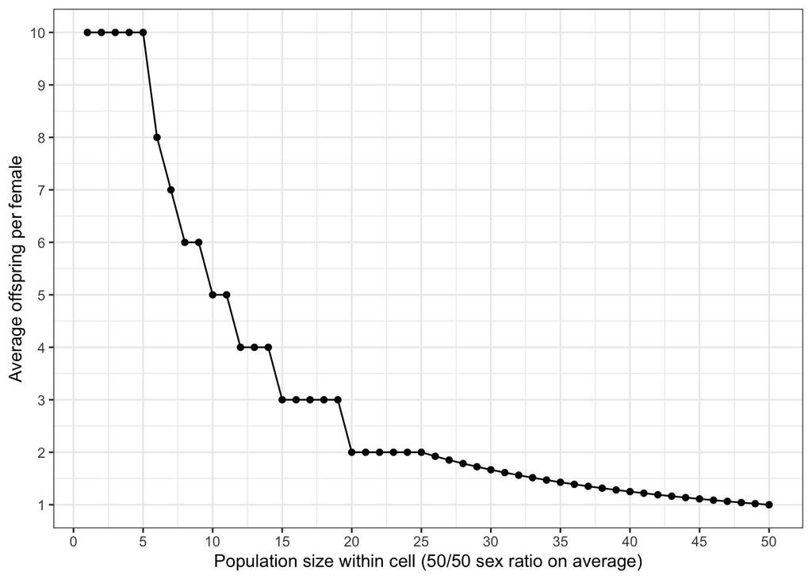

**Figure SM1c:** How the number of offspring produced per female differs based upon population size within a grid cell.

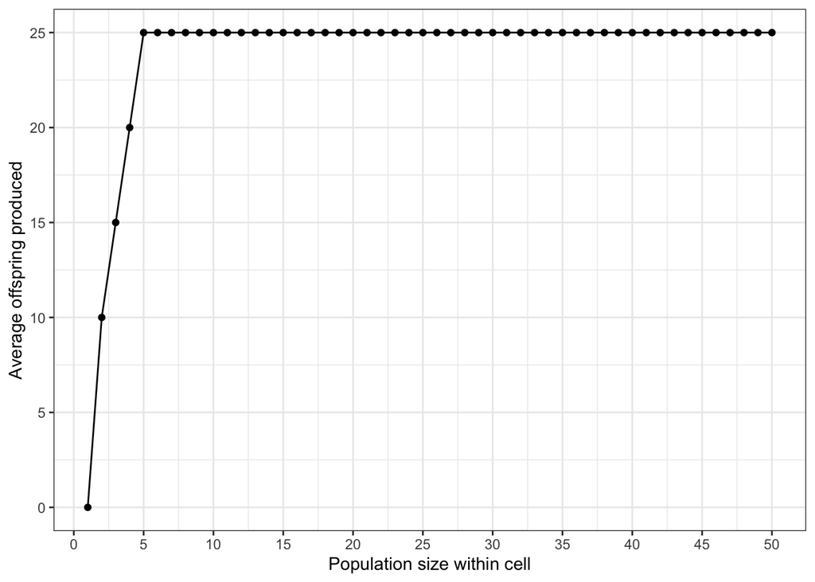

**Figure SM1d:** How population size within a cell relates to the number of offspring produced.

#### Natal dispersal

For each female that produces offspring, the offspring will have a starting location half-way between the mother and fathers breeding location. From this location the offspring then undertakes natal dispersal. The direction of this dispersal movement is chosen at random, and the distance is drawn at random from a Gamma distribution with n of 10,000, a rate parameter of 0.0001, and a shape parameter that is varied to produce varying mean breeding dispersal movement distances. This new location is then the breeding locations for these offspring, such that this can be thought of as a pre-migratory dispersal to find the future breeding ground. Any individuals that disperse outside of the breeding range are then removed from the population.

#### Inherited distance & direction of migration

Each offspring is given an inherited migratory distance and direction. This is achieved by taking the mean latitudinal and longitudinal distances between each of the parents breeding and non-breeding locations, to give a genetically encoded non-breeding destination that is half-way between the two parents non-breeding locations. For each individual, there is a 1 in 1/mutation rate chance of the genetically inherited programme mutating (e.g., for a mutation rate of 0.01 this is a 1 in 100 chance). When a mutation occurs the inherited non-breeding location is shifted a random direction with a distance drawn from Gamma distribution with n of 10,000, a rate parameter of 0.0001, and a shape parameter that is varied to produce varying mean mutation ‘sizes’. The result is a new genetic non-breeding destination where the distance and direction have both been altered.

#### Non-heritable non-breeding dispersal

For each individual, additional non-breeding dispersal is incurred due to non-heritable factors such as a species-level ability to follow the inherited distance and direction, and environmental factors such as wind drift. To emulate this, each individual is shifted in a random direction from its genetically encoded non-breeding destination with a distance drawn from a Gamma distribution with n of 10,000, a rate parameter of 0.0001, and a shape parameter that is varied to produce varying mean non-inheritable non-breeding dispersal distances. This is then the final non-breeding location for that individual. Any individual that is outside of the non-breeding zone is removed from the population.

#### Repeat

This process is looped on a yearly iteration for a total of 500 iterations (years). All breeding adults are removed at the end of each iteration and offspring breed in their second year. Measured migratory connectivity is therefore for the previous years’ offspring.

#### Measuring connectivity

At the start of each yearly iteration 100 individuals are sampled at random from the breeding range and corresponding individuals non-breeding locations are also taken. Pairwise distances are measured for both regions and the strength of migratory connectivity is measured using the function `mantel.rtest()`. As such the measured connectivity is for the previous year and for the first iteration of the burn-in phase this Mantel score will always be 1.

The process was repeated 100 times to produce 100 replicates. Each replicate was split into nine sections and run in parallel on the University of East Anglia High Performance Computing (HPC) cluster, which uses a SLURM job handler. The burn-in code shown below may therefore be prohibitively slow to run on a single system and the code chunk `Sys.getenv('SLURM_ARRAY_TASK_ID')` may not work on your system.

#### Full burn-in code

Full code used to implement the burn-in. To reduce computation time the following code was split into nine sub-sections based on combination of fixed value of variables `g` and `s` with each sub-section run concurrently. This had no effect on simulation results as these sub-sections are independent of one another.

```r
# Initial set up ----

brd_latrange <- c(quantile(xy$y,0.67),quantile(xy$y,1))
brd_lonrange <- c(quantile(xy$x,0),quantile(xy$x,1))
win_latrange <- c(quantile(xy$y,0),quantile(xy$y,0.33))
win_lonrange  <- c(quantile(xy$x,0),quantile(xy$x,1))

# Function to count individuals per raster grid cell
pointcount = function(r, pts){
  # make a raster of zeroes like the input
  r2 = r
  r2[] = 0
  # get the cell index for each point and make a table:
  counts = table(cellFromXY(r,pts))
  # fill in the raster with the counts from the cell index:
  r2[as.numeric(names(counts))] = counts
  return(r2)
}

n <- 10000 # Set total population carrying capacity
years <- 500 # Number of years of burn-in period
sampled <- 100 # Number of individuals sampled for migratory connectivity test (Mantel)

con.levs <- c(.0001) # Rate parameter for rgamma function (one of two parameters that controls kernel distribution)
Genetic_shape <- c(0.5, 1.5, 3) # Shape parameters used with rgamma function
mutation_rate <- c(0.01,0.1,0.5)

### Create empty data sheets and lists for data storage
data_sheet <- data.frame(matrix(ncol=2, nrow=years))
data_sheet[,1] <- seq(1,years)
colnames(data_sheet) <- c('Iteration','Mantel')
data <- list()
counter <- 0

# Starting locations - same for every iteration

starting_brd_locs <- read.csv('burnin_start_brd.csv')
starting_win_locs <- read.csv('burnin_start_win.csv')


#### main loop ----
for(g in 1:3){ # non-breeding dispersal (genetic mutation shape (size))
  for (s in 1:3){ # non-breeding dispersal (genetic mutation rate)
    for(b in 1:3){ # breeding dispersal
      for(z in 1:3){ # non-breeding dispersal (environmental noise shape (size))
        # Intitial popualtion #
        brd_locs <- starting_brd_locs
        win_locs <- starting_win_locs
        parent_win_start <- starting_win_locs

        for(i in 1:years){
          ### Yearly iterated loop #

          ### Sample individuals and measure MC. Only adults are sampled (This years offspring not included yet)
          # If pop size is too low to take sample desired, just take all (can happen with low yearly survival and/or very high dispersal based mortality)
          if(nrow(brd_locs) >= sampled){
            inds <- sample(brd_locs$individual,sampled)
          }else{
            inds <- brd_locs$individual}

          brd_samp_inds <- subset(brd_locs, brd_locs$individual %in% inds)
          win_samp_inds <- subset(win_locs, win_locs$individual %in% inds)
          brddists <- dist(brd_samp_inds[1:2])
          windists <- dist(win_samp_inds[1:2])
          mantel <- mantel.rtest(brddists,windists,nrepet=1)

          data_sheet[i,2] <- mantel$obs
          data_sheet$nbd <- Genetic_shape[z]
          data_sheet$bd <- Genetic_shape[b]
          data_sheet$Mutation_rate <- mutation_rate[s]
          data_sheet$pop_size[i] <- nrow(brd_locs)

          ### Produce offspring locations ###
          # Apply density dependent breeding - choose adults to breed
          # Number of offspring fills K (times a modifier to offset effect of dispersal out of range) to prevent extinction (this is logarithmic density dependence with cap of mean offspring of 10 per ind)

          densityrast <- raster(nrow=20,ncol=20)
          extent(densityrast) <- c(0,1,1.33, 2)
          r <- pointcount(densityrast, brd_locs)
          cellvals <- data.frame(raster::extract(r, brd_locs[1:2], cellnumbers=TRUE))
          names(cellvals)[2] <- 'local_density'
          brd_locs <- cbind(brd_locs[1:4], cellvals)
          df1 <- data.frame()
          # Within each grid cell apply logarithmic? density dependence with cap
          for(c in unique(cellvals$cells)){
            temp <- subset(brd_locs, cells == c)
            # Calculate breeding modifier
            brd_mod <- (n/ncell(densityrast))/(temp$local_density)[1]
            if(brd_mod > 5){
              brd_mod <- 5}
            # Randomly choose individuals within grid cell to potentially breed. Number taken based upon number of inds. x density denpendent breeding modifier
            #temp2 <- temp[sample(rownames(temp), nrow(temp)*brd_mod, replace=T),]

            fems <- subset(temp, Sex == 'Female')
            males <- subset(temp, Sex == 'Male')

            if(nrow(males)==0|nrow(fems)==0){next}

            for (a in fems$individual){
              fem <- fems[fems$individual==a,]
              male <- males[sample(rownames(males), 1),]

              if(brd_mod*2 < 2){
                if(sample(seq(100,200),1) < round(brd_mod*2, 2)*100){rows=2}else{rows=1}
                os <- data.frame(matrix(nrow=rows, ncol=6))
              }else{
                os <- data.frame(matrix(nrow=round(brd_mod*2), ncol=6))}

              names(os) <- c('x', 'y', 'individual', 'Sex', 'Mum', 'Dad')

              # parental_inheritance == 'half_way'

              os$x <- (fem$x + male$x)/2
              os$y <- (fem$y + male$y)/2

              labs <- c('Male','Female')
              os$Sex <- gl(n=2, k=1, length=nrow(os),labels=sample(labs, 2))
              os$Mum <- fem$individual
              os$Dad <- male$individual
              df1 <- rbind(df1, os)
            }
          }
          # offspring is carrying capacity (K) * 1.2 to account for dispersal related mortality

          if(nrow(df1)>=(n)){
            OS_locs <- df1[sample(rownames(df1), n, replace=F),]
          }else{
            OS_locs <- df1
          }
          brd_dispersal <- rgamma(nrow(OS_locs), shape=Genetic_shape[b], rate=con.levs[1])

          direction <- runif(nrow(OS_locs),-180,180)
          offspring_locs<- destPointRhumb(OS_locs[1:2], direction, d=brd_dispersal)
          offspring_locs <- as.data.frame(offspring_locs)

          # Give them individual ID that follows on from previous generation
          offspring_locs$individual <-
            seq(max(as.numeric(brd_locs$individual)+1), (max(as.numeric(brd_locs$individual))+(nrow(offspring_locs))))
          offspring_locs$Sex <- OS_locs$Sex
          # Second copy of offspring locations with parent ID included
          offspring_locs2 <- offspring_locs
          offspring_locs2$Mum <- OS_locs$Mum
          offspring_locs2$Dad <- OS_locs$Dad
          parent_brd_locs <- brd_locs
          brd_locs <- offspring_locs

          # Remove individuals that have dispersed out of habitable zone (won't be breeding adults next year)
          names(brd_locs)[1:2] <- c('x','y')
          brd_locs <- subset(data.frame(brd_locs), subset = x>=0 & x<=1 & y>=1.33 & y<=2)

          ### Non-breeding dispersal of juveniles ###

          # Remove individuals that have dispersed out of habitable zone
          offspring_locs <- subset(offspring_locs, offspring_locs$individual %in% brd_locs$individual)
          win_dispersal <- rgamma(nrow(offspring_locs), shape=Genetic_shape[z], rate=con.levs[1])
          direction <- runif(nrow(offspring_locs),-180,180)

          # Inherticance of winter locs, go to parents non-breeding loc before dispersal
          names(offspring_locs2)[1:2] <- c('x','y')
          offspring_locs2 <- subset(data.frame(offspring_locs2), subset = x>=0 & x<=1 & y>=1.33 & y<=2) # remove inds in non-habitable zone

          names(win_locs)[1:2] <- c('x','y')
          parent_win_locs <- win_locs # win_locs at this point are inds from previous iteration
          names(parent_win_locs)[3] <- 'parent'

          wint_os_start <- data.frame()

          for(q in rownames(offspring_locs2)){
            wint_os <- offspring_locs2[q,]

            mum_brd <- parent_brd_locs[parent_brd_locs$individual==wint_os$Mum,]
            dad_brd <- parent_brd_locs[parent_brd_locs$individual==wint_os$Dad,]
            mum_win <- parent_win_start[parent_win_start$individual==wint_os$Mum,]
            dad_win <- parent_win_start[parent_win_start$individual==wint_os$Dad,]

            mum_lat <- diff(c(mum_brd$y,mum_win$y))
            mum_lon <- diff(c(mum_brd$x,mum_win$x))
            dad_lat <- diff(c(dad_brd$y,dad_win$y))
            dad_lon <- diff(c(dad_brd$x,dad_win$x))

            temp_brd <- brd_locs[brd_locs$individual==wint_os$individual,]

            # parental_inheritance == 'half_way'

            lat_move <- mean(c(mum_lat,dad_lat))
            lon_move <- mean(c(mum_lon,dad_lon))

            wint_os$x <- temp_brd$x + lon_move
            wint_os$y <- temp_brd$y + lat_move

            if(sample(1:(1/mutation_rate[s]),1)==1){
              wint_os2 <- destPointRhumb(wint_os[1:2], sample(direction,1), d=sample(rgamma(10000, shape=Genetic_shape[g], rate=con.levs[1]), 1))
              wint_os[1:2] <- wint_os2[1:2]
            }

            wint_os_start <- rbind(wint_os_start, wint_os)
          }

          parent_win_start <- wint_os_start

          offspring_win_locs <- destPointRhumb(wint_os_start[1:2], direction, d=win_dispersal)
          offspring_win_locs <- data.frame(offspring_win_locs)
          offspring_win_locs$individual <- wint_os_start$individual
          offspring_win_locs$Sex <- wint_os_start$Sex

          # Offspring become the only adults for next iteration
          win_locs <- offspring_win_locs

          names(win_locs)[1:2] <- c('x','y')
          # Remove inds from outside habitable zone
          win_locs <- subset(win_locs, subset = x>=0 & x<1 & y>0 & y<=.66)
          brd_locs <- subset(brd_locs, brd_locs$individual %in% win_locs$individual)
          # Had issues with a winter ind being duplicated in some instances, this removes potential
          win_locs <- win_locs[!duplicated(win_locs$individual),]
          brd_locs <- brd_locs[!duplicated(brd_locs$individual),]
          names(win_locs)[1:2] <- c('x','y')
          names(brd_locs)[1:2] <- c('x','y')

          # enact density dependent survival

          densityrast2 <- raster(nrow=20,ncol=20)
          extent(densityrast2) <- c(0,1,0, 0.66)
          r2 <- pointcount(densityrast2, win_locs)
          cellvals2 <- data.frame(raster::extract(r2, win_locs[1:2], cellnumbers=TRUE))
          names(cellvals2)[2] <- 'local_density'
          win_locs <- cbind(win_locs[1:4], cellvals2)
          df2 <- data.frame()
          # Within each grid cell apply logarithmic? density dependence with cap
          if(max(cellvals2$local_density) > 25){
            for(c in unique(cellvals2$cells)){
              temp2 <- subset(win_locs, cells == c)
              if(length(rownames(temp2)) > 25){
                temp2 <- temp2[!rownames(temp2) %in% sample(rownames(temp2), abs(25-nrow(temp2)), replace=F),]
              }
              df2 <- rbind(df2, temp2)

            }
            df2 <- df2[order(as.numeric(rownames(df2))),]
            win_locs <- df2
            brd_locs <- subset(brd_locs, brd_locs$individual %in% win_locs$individual)
          }
        }

        counter <- counter+1
        data[[counter]] <- data_sheet

        numrun <- as.numeric(Sys.getenv('SLURM_ARRAY_TASK_ID'))
        write.csv(brd_locs, file=paste0(numrun,b,z,'G',g,'S',s,'brd_locs.csv'))), row.names = F)
        write.csv(win_locs, file=paste0(numrun,b,z,'G',g,'S',s,'win_locs.csv'))), row.names = F)

      }

    }}}
# Combine list of data
alldata <- rbindlist(data)
write.csv(alldata, file=paste0(numrun,'alldata.csv'), row.names = F)
```

#### Burn-in results

The burn-in phase produced 8100 populations (100 replicates of the 81 unique combinations of variables measured) that rapidly reached long-term stable population size and Mantel scores around relatively small annual stochastic variation. Stochasticity is a result of the random sampling of the distance kernels as well as sample size related precision in Mantel scores when measuring migratory connectivity.

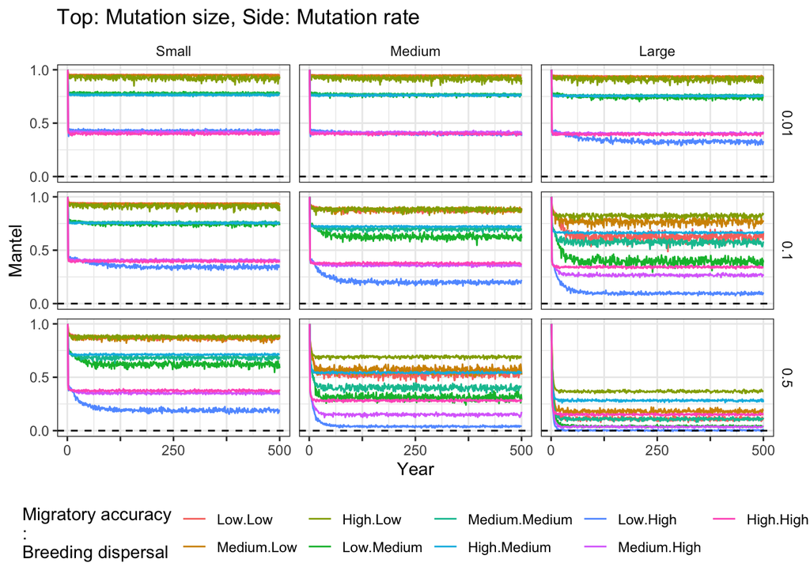

**Figure SM1e:** Mantel scores through the burn-in period. Lines are for averaged scores across the 100 replicates.

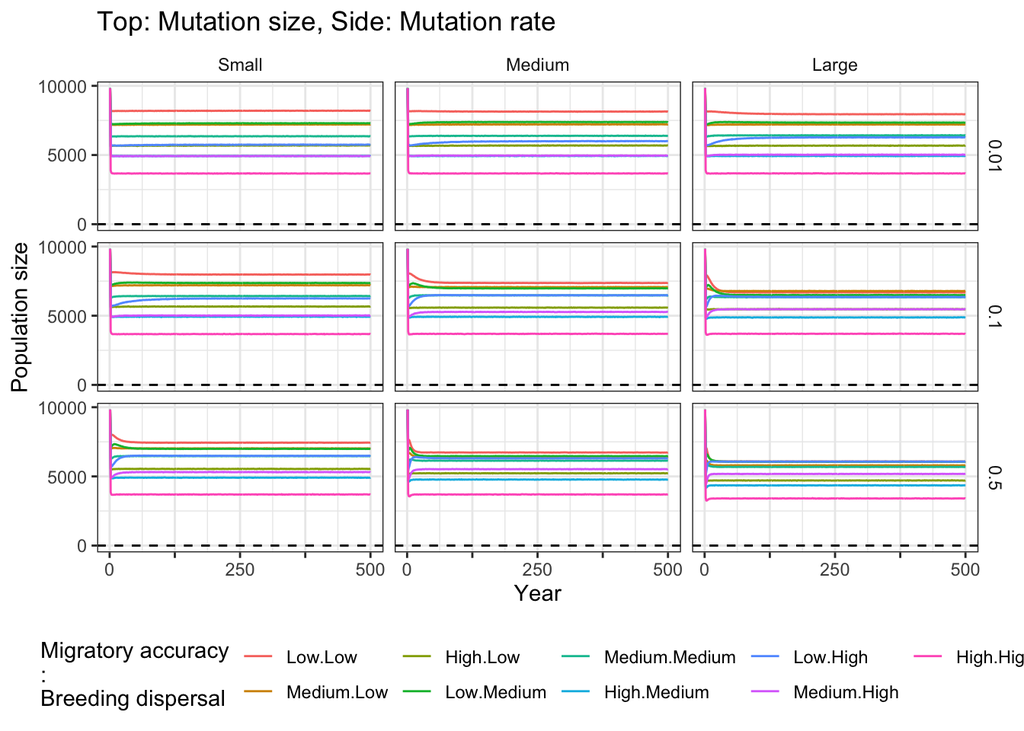

**Figure SM1f:** Population sizes through the burn-in period. Lines are for averaged scores across the 100 replicates.

### Enacting range shift

After the 500-year burn-in period finishes, annual incremental range shifts are enacted for a 50-year period.Range shifts were undertaken with two distinct types – coupled and uncoupled.

Populations were taken from the end point of the burn-in phase, such that the first iteration of the range shift period is year 501. From here the iterative yearly process continues along the parameters and methodology set out in the burn-in phase, with the addition of shifting habitable zones.

#### Coupled

Both ranges shift in a northerly direction at the same rate. Rate of change was 0.02/year (coordinate units, ranges both have coordinate heights of 0.66).

```r
#### Initial population set up ----

# 1.1: Set up data and objects for simulations #

# Set up the environment space:
xdim <- 100  # x dimension of space
ydim <- xdim * 2  # y dimension of space
grid <- raster(ncols = ydim, nrows = ydim)  # create a grid of cells in raster format
extent(grid) <- c(0, 1, 0, ydim/xdim)  # set up extent of the grid object
grid[] <- 1
xy <- data.frame(xyFromCell(grid, 1:ncell(grid)))  #extract coords of cell centres
brd_latrange <- c(quantile(xy$y, 0.67), quantile(xy$y, 1))
brd_lonrange <- c(quantile(xy$x, 0), quantile(xy$x, 1))
win_latrange <- c(quantile(xy$y, 0), quantile(xy$y, 0.33))
win_lonrange <- c(quantile(xy$x, 0), quantile(xy$x, 1))

# Function to count individuals per raster grid cell
pointcount = function(r, pts) {
    # make a raster of zeroes like the input
    r2 = r
    r2[] = 0
    # get the cell index for each point and make a table:
    counts = table(cellFromXY(r, pts))
    # fill in the raster with the counts from the cell index:
    r2[as.numeric(names(counts))] = counts
    return(r2)
}

#### Section 3: induce range shifts ---- Customisable parameters

n <- 10000  # set a total population size
years <- 50  # number of years population is observed
sampled <- 100  # individuals sampled for MC

### Dispersal distributions
con.levs <- c(0.0001)  # levels used for rgamma
shape <- c(0.5, 1.5, 3)
Genetic_shape <- c(0.5, 1.5, 3)
mutation_rate <- c(0.01, 0.1, 0.5)

# starting ranges
BRlat1 <- 1.33
BRlat2 <- 2
BRlon1 <- 0
BRlon2 <- 1

WRlat1 <- 0
WRlat2 <- 0.66
WRlon1 <- 0
WRlon2 <- 1

# Yearly range shifts (value added on to range latitudes)

# Tracking
breeding_rangeshift <- 0.02
nonbreeding_rangeshift <- 0.02

### Empty data sheets and lists - run before each run of the loop
data_sheet <- data.frame(matrix(ncol = 2, nrow = years))
data_sheet[, 1] <- seq(1, years)
colnames(data_sheet) <- c("Iteration", "Mantel")
data <- list()
counter <- 0

#### main loop ----

for (g in 1:3) {
    # Genetic shape non-breeding dispersal (genetic mutation rate) breeding
    # dispersal non-breeding dispersal (environmental) Intitial popualtion #
    for (s in 1:3) {
        for (b in 1:3) {
            for (z in 1:3) {

                numrun <- as.numeric(Sys.getenv("SLURM_ARRAY_TASK_ID"))
                brd_locs <- read.csv(paste0("./DD_populations/", paste0(numrun, paste0(b,
                  paste0(z, paste0("G", paste0(g, paste0("S", paste0(s, "brd_locs.csv")))))))))

                win_locs <- read.csv(paste0("./DD_populations/", paste0(numrun, paste0(b,
                  paste0(z, paste0("G", paste0(g, paste0("S", paste0(s, "win_locs.csv")))))))))

                parent_win_start <- win_locs

                # reset ranges
                BRlat1.5 <- BRlat1
                BRlat2.5 <- BRlat2
                WRlat1.5 <- WRlat1
                WRlat2.5 <- WRlat2

                data_sheet$Mantel <- 0
                data_sheet$nbd <- 0
                data_sheet$bd <- 0
                data_sheet$Mutation_rate <- 0
                data_sheet$genetic_shape <- 0
                data_sheet$pop_size <- 0
                data_sheet$replicate <- 0
                data_sheet$shift <- 0

                for (i in 1:years) {
                  ### Yearly iterated loop # Sample individuals and measure MC.
                  ### Only adults are sampled (This years offspring not
                  ### included yet) If pop size is too low to take sample
                  ### desired, just take all (can happen with low yearly
                  ### survival and/or very high dispersal based mortality)
                  if (nrow(brd_locs) >= sampled) {
                    inds <- sample(brd_locs$individual, sampled)
                  } else {
                    inds <- brd_locs$individual
                  }

                  if (nrow(brd_locs) < 50) {
                    next
                  }

                  brd_samp_inds <- subset(brd_locs, brd_locs$individual %in% inds)
                  win_samp_inds <- subset(win_locs, win_locs$individual %in% inds)

                  brddists <- dist(brd_samp_inds[1:2])
                  windists <- dist(win_samp_inds[1:2])
                  mantel <- mantel.rtest(brddists, windists, nrepet = 1)

                  data_sheet[i, 2] <- mantel$obs
                  data_sheet$nbd <- shape[z]
                  data_sheet$bd <- shape[b]
                  data_sheet$Mutation_rate <- mutation_rate[s]
                  data_sheet$genetic_shape <- Genetic_shape[g]
                  data_sheet$pop_size[i] <- nrow(brd_locs)
                  data_sheet$replicate <- numrun
                  data_sheet$shift <- "Tracking"

                  ### Produce offspring locations ### Apply density dependent
                  ### breeding - choose adults to breed Number of offspring
                  ### fills K (times a modifier to offset effect of dispersal
                  ### out of range) to prevent extinction (this is logarithmic
                  ### density dependence with cap of mean offspring of 10 per
                  ### ind)

                  if (nrow(brd_locs) < 50) {
                    next
                  }

                  densityrast <- raster(nrow = 20, ncol = 20)
                  extent(densityrast) <- c(0, 1, BRlat1.5, BRlat2.5)
                  brd_locs <- subset(data.frame(brd_locs), subset = x >= 0 & x <=
                    1 & y >= BRlat1.5 & y <= BRlat2.5)
                  r <- pointcount(densityrast, brd_locs)
                  cellvals <- data.frame(raster::extract(r, brd_locs[1:2], cellnumbers = TRUE))

                  names(cellvals)[2] <- "local_density"
                  brd_locs <- cbind(brd_locs[1:4], cellvals)
                  df1 <- data.frame()
                  # Within each grid cell apply logarithmic? density dependence
                  # with cap
                  for (c in unique(cellvals$cells)) {
                    temp <- subset(brd_locs, cells == c)
                    # Calculate breeding modifier
                    brd_mod <- (n/ncell(densityrast))/first(temp$local_density)
                    if (brd_mod > 5) {
                      brd_mod <- 5
                    }
                    # Randomly choose individuals within grid cell to
                    # potentially breed. Number taken based upon number of
                    # inds. x density denpendent breeding modifier
```

```r
                    fems <- subset(temp, Sex == "Female")
                    males <- subset(temp, Sex == "Male")

                    if (nrow(males) == 0 | nrow(fems) == 0) {
                      next
                    }

                    for (a in fems$individual) {
                      fem <- fems[fems$individual == a, ]
                      male <- males[sample(rownames(males), 1), ]

                      if (brd_mod * 2 < 2) {
                        if (sample(seq(100, 200), 1) < round(brd_mod * 2, 2) * 100) {
                          rows = 2
                        } else {
                          rows = 1
                        }
                        os <- data.frame(matrix(nrow = rows, ncol = 6))
                      } else {
                        os <- data.frame(matrix(nrow = round(brd_mod * 2), ncol = 6))
                      }

                      names(os) <- c("x", "y", "individual", "Sex", "Mum", "Dad")

                      # parental_inheritance == 'half_way'
                      os$x <- (fem$x + male$x)/2
                      os$y <- (fem$y + male$y)/2

                      labs <- c("Male", "Female")
                      os$Sex <- gl(n = 2, k = 1, length = nrow(os), labels = sample(labs,
                        2))
                      os$Mum <- fem$individual
                      os$Dad <- male$individual
                      labs <- c("Male", "Female")
                      df1 <- rbind(df1, os)
                    }
                  }
                  # offspring is carrying capacity (K) * 1.2 to account for
                  # dispersal related mortality
                  if (nrow(df1) >= (n)) {
                    OS_locs <- df1[sample(rownames(df1), n, replace = F), ]
                  } else {
                    OS_locs <- df1
                  }
                  if (nrow(OS_locs) == 0) {
                    next
                  }
                  brd_dispersal <- rgamma(nrow(OS_locs), shape = shape[b], rate = con.levs[1])

                  direction <- runif(nrow(OS_locs), -180, 180)
                  offspring_locs <- destPointRhumb(OS_locs[1:2], direction, d = brd_dispersal)
                  offspring_locs <- as.data.frame(offspring_locs)

                  # Give them individual ID that follows on from previous
                  # generation
                  offspring_locs$individual <- seq(max(as.numeric(brd_locs$individual) +
                    1), (max(as.numeric(brd_locs$individual)) + (nrow(offspring_locs))))
                  offspring_locs$Sex <- OS_locs$Sex
                  # Second copy of offspring locations with parent ID included
                  offspring_locs2 <- offspring_locs
                  offspring_locs2$Mum <- OS_locs$Mum
                  offspring_locs2$Dad <- OS_locs$Dad

                  parent_brd_locs <- brd_locs
                  brd_locs <- offspring_locs

                  # Remove individuals that have dispersed out of habitable
                  # zone (won't be breeding adults next year)
                  names(brd_locs)[1:2] <- c("x", "y")
                  brd_locs <- subset(data.frame(brd_locs), subset = x >= 0 & x <=
                    1 & y >= BRlat1.5 & y <= BRlat2.5)
                  ### Non-breeding dispersal of juveniles ### Remove
                  ### individuals that have dispersed out of habitable zone
                  offspring_locs <- subset(offspring_locs, offspring_locs$individual %in%
                    brd_locs$individual)
                  win_dispersal <- rgamma(nrow(offspring_locs), shape = shape[z],
                    rate = con.levs[1])

                  direction <- runif(nrow(offspring_locs), -180, 180)

                  # Inherticance of winter locs, go to parents non-breeding loc
                  # before dispersal
                  names(offspring_locs2)[1:2] <- c("x", "y")
                  offspring_locs2 <- subset(data.frame(offspring_locs2), subset = x >=
                    0 & x <= 1 & y >= BRlat1.5 & y <= BRlat2.5)  # remove inds in non-habitable zone

                  names(win_locs)[1:2] <- c("x", "y")
                  parent_win_locs <- win_locs  # win_locs at this point are inds from previous iteration
                  names(parent_win_locs)[3] <- "parent"

                  wint_os_start <- data.frame()

                  for (q in rownames(offspring_locs2)) {
                    wint_os <- offspring_locs2[q, ]

                    mum_brd <- parent_brd_locs[parent_brd_locs$individual == wint_os$Mum,
                      ]
                    dad_brd <- parent_brd_locs[parent_brd_locs$individual == wint_os$Dad,
                      ]
                    mum_win <- parent_win_start[parent_win_start$individual == wint_os$Mum,
                      ]
                    dad_win <- parent_win_start[parent_win_start$individual == wint_os$Dad,
                      ]

                    mum_lat <- diff(c(mum_brd$y, mum_win$y))
                    mum_lon <- diff(c(mum_brd$x, mum_win$x))
                    dad_lat <- diff(c(dad_brd$y, dad_win$y))
                    dad_lon <- diff(c(dad_brd$x, dad_win$x))

                    temp_brd <- brd_locs[brd_locs$individual == wint_os$individual,
                      ]

                    # (parental_inheritance == 'half_way')

                    lat_move <- mean(c(mum_lat, dad_lat))
                    lon_move <- mean(c(mum_lon, dad_lon))

                    wint_os$x <- temp_brd$x + lon_move
                    wint_os$y <- temp_brd$y + lat_move

                    if (sample(1:(1/mutation_rate[s]), 1) == 1) {
                      wint_os2 <- destPointRhumb(wint_os[1:2], sample(direction,
                        1), d = sample(rgamma(10000, shape = Genetic_shape[g], rate = con.levs[1]),
                        1))
                      wint_os[1:2] <- wint_os2[1:2]
                    }

                    wint_os_start <- rbind(wint_os_start, wint_os)
                  }

                  parent_win_start <- wint_os_start
```

```r
                  offspring_win_locs <- destPointRhumb(wint_os_start[1:2], direction,
                    d = win_dispersal)
                  offspring_win_locs <- data.frame(offspring_win_locs)
                  offspring_win_locs$individual <- wint_os_start$individual
                  offspring_win_locs$Sex <- wint_os_start$Sex

                  # Offspring become the only adults for next iteration
                  win_locs <- offspring_win_locs

                  names(win_locs)[1:2] <- c("x", "y")
                  # Remove inds from outside habitable zone
                  win_locs <- subset(win_locs, subset = x >= 0 & x < 1 & y > WRlat1.5 &
                    y <= WRlat2.5)
                  brd_locs <- subset(brd_locs, brd_locs$individual %in% win_locs$individual)
                  # Had issues with a winter ind being duplicated in some
                  # instances, this removes potential
                  win_locs <- win_locs[!duplicated(win_locs$individual), ]
                  brd_locs <- brd_locs[!duplicated(brd_locs$individual), ]
                  names(win_locs)[1:2] <- c("x", "y")
                  names(brd_locs)[1:2] <- c("x", "y")

                  # enact density dependent survival

                  densityrast2 <- raster(nrow = 20, ncol = 20)
                  extent(densityrast2) <- c(0, 1, WRlat1.5, WRlat2.5)
                  r2 <- pointcount(densityrast2, win_locs)
                  cellvals2 <- data.frame(raster::extract(r2, win_locs[1:2], cellnumbers = TRUE))
                  names(cellvals2)[2] <- "local_density"
                  win_locs <- cbind(win_locs[1:4], cellvals2)
                  df2 <- data.frame()
                  # Within each grid cell apply logarithmic? density dependence
                  # with cap
                  if (max(cellvals2$local_density) > 50) {
                    for (c in unique(cellvals2$cells)) {
                      temp2 <- subset(win_locs, cells == c)
                      if (length(rownames(temp2)) > 50) {
                        temp2 <- temp2[!rownames(temp2) %in% sample(rownames(temp2),
                          abs(50 - nrow(temp2)), replace = F), ]
                      }
                      df2 <- rbind(df2, temp2)

                    }
                    df2 <- df2[order(as.numeric(rownames(df2))), ]
                    win_locs <- df2
                    brd_locs <- subset(brd_locs, brd_locs$individual %in% win_locs$individual)
                  }

                  # range shift occurs at end of year n (after breeding and
                  # dispersal) and impacts year n+1 breeding

                  if (i > 0 & i < 51) {
                    BRlat1.5 <- BRlat1.5 + breeding_rangeshift
                    BRlat2.5 <- BRlat2.5 + breeding_rangeshift
                    WRlat1.5 <- WRlat1.5 + nonbreeding_rangeshift
                    WRlat2.5 <- WRlat2.5 + nonbreeding_rangeshift
                  }
                }
                counter <- counter + 1
                data[[counter]] <- data_sheet
            }
        }
    }
}

# Combine list of data
alldata <- rbindlist(data)
numrun <- as.numeric(Sys.getenv("SLURM_ARRAY_TASK_ID"))
write.csv(alldata, file = paste0(numrun, "rangeshift_track.csv"), row.names = F)
```

#### Uncoupled

Both ranges shift in a northerly direction but at different rates. Rate of change for the breeding range was 0.02/year, and for the non-breeding range it was 0.01/year year (coordinate units, ranges both have coordinate heights of 0.66).

```r
#### Initial population set up ----

# 1.1: Set up data and objects for simulations #

# Set up the environment space:
xdim <- 100  # x dimension of space
ydim <- xdim * 2  # y dimension of space
grid <- raster(ncols = ydim, nrows = ydim)  # create a grid of cells in raster format
extent(grid) <- c(0, 1, 0, ydim/xdim)  # set up extent of the grid object
grid[] <- 1
xy <- data.frame(xyFromCell(grid, 1:ncell(grid)))  #extract coords of cell centres
brd_latrange <- c(quantile(xy$y, 0.67), quantile(xy$y, 1))
brd_lonrange <- c(quantile(xy$x, 0), quantile(xy$x, 1))
win_latrange <- c(quantile(xy$y, 0), quantile(xy$y, 0.33))
win_lonrange <- c(quantile(xy$x, 0), quantile(xy$x, 1))

# Function to count individuals per raster grid cell
pointcount = function(r, pts) {
    # make a raster of zeroes like the input
    r2 = r
    r2[] = 0
    # get the cell index for each point and make a table:
    counts = table(cellFromXY(r, pts))
    # fill in the raster with the counts from the cell index:
    r2[as.numeric(names(counts))] = counts
    return(r2)
}


#### Section 3: induce range shifts ---- Customisable parameters

n <- 10000  # set a total population size
years <- 50  # number of years population is observed
sampled <- 100  # individuals sampled for MC

### Dispersal distributions
con.levs <- c(0.0001)  # levels used for rgamma
shape <- c(0.5, 1.5, 3)
Genetic_shape <- c(0.5, 1.5, 3)
mutation_rate <- c(0.01, 0.1, 0.5)

# starting ranges
BRlat1 <- 1.33
BRlat2 <- 2
BRlon1 <- 0
BRlon2 <- 1

WRlat1 <- 0
WRlat2 <- 0.66
WRlon1 <- 0
WRlon2 <- 1

# Yearly range shifts (value added on to range latitudes)

# Tracking
breeding_rangeshift <- 0.02
nonbreeding_rangeshift <- 0.01

### Empty data sheets and lists - run before each run of the loop
data_sheet <- data.frame(matrix(ncol = 2, nrow = years))
data_sheet[, 1] <- seq(1, years)
colnames(data_sheet) <- c("Iteration", "Mantel")
data <- list()
counter <- 0

#### main loop ----

for (g in 1:3) {
    # Genetic shape non-breeding dispersal (genetic mutation rate) breeding
    # dispersal non-breeding dispersal (environmental) Intitial popualtion #
    for (s in 1:3) {
        for (b in 1:3) {
            for (z in 1:3) {

                numrun <- as.numeric(Sys.getenv("SLURM_ARRAY_TASK_ID"))
                brd_locs <- read.csv(paste0("./DD_populations/", paste0(numrun, paste0(b,
                  paste0(z, paste0("G", paste0(g, paste0("S", paste0(s, "brd_locs.csv")))))))))

                win_locs <- read.csv(paste0("./DD_populations/", paste0(numrun, paste0(b,
                  paste0(z, paste0("G", paste0(g, paste0("S", paste0(s, "win_locs.csv")))))))))

                parent_win_start <- win_locs

                # reset ranges
                BRlat1.5 <- BRlat1
                BRlat2.5 <- BRlat2
                WRlat1.5 <- WRlat1
                WRlat2.5 <- WRlat2

                data_sheet$Mantel <- 0
                data_sheet$nbd <- 0
                data_sheet$bd <- 0
                data_sheet$Mutation_rate <- 0
                data_sheet$genetic_shape <- 0
                data_sheet$pop_size <- 0
                data_sheet$replicate <- 0
                data_sheet$shift <- 0

                for (i in 1:years) {
                  ### Yearly iterated loop # Sample individuals and measure MC.
                  ### Only adults are sampled (This years offspring not
                  ### included yet) If pop size is too low to take sample
                  ### desired, just take all (can happen with low yearly
                  ### survival and/or very high dispersal based mortality)
                  if (nrow(brd_locs) >= sampled) {
                    inds <- sample(brd_locs$individual, sampled)
                  } else {
                    inds <- brd_locs$individual
                  }

                  if (nrow(brd_locs) < 50) {
                    next
                  }

                  brd_samp_inds <- subset(brd_locs, brd_locs$individual %in% inds)
                  win_samp_inds <- subset(win_locs, win_locs$individual %in% inds)

                  brddists <- dist(brd_samp_inds[1:2])
                  windists <- dist(win_samp_inds[1:2])
                  mantel <- mantel.rtest(brddists, windists, nrepet = 1)

                  data_sheet[i, 2] <- mantel$obs
                  data_sheet$nbd <- shape[z]
                  data_sheet$bd <- shape[b]
                  data_sheet$Mutation_rate <- mutation_rate[s]
                  data_sheet$genetic_shape <- Genetic_shape[g]
                  data_sheet$pop_size[i] <- nrow(brd_locs)
                  data_sheet$replicate <- numrun
                  data_sheet$shift <- "Uncoupled"

                  ### Produce offspring locations ### Apply density dependent
                  ### breeding - choose adults to breed Number of offspring
                  ### fills K (times a modifier to offset effect of dispersal
                  ### out of range) to prevent extinction (this is logarithmic
                  ### density dependence with cap of mean offspring of 10 per
                  ### ind)

                  densityrast <- raster(nrow = 20, ncol = 20)
                  extent(densityrast) <- c(0, 1, BRlat1.5, BRlat2.5)
                  brd_locs <- subset(data.frame(brd_locs), subset = x >= 0 & x <=
                    1 & y >= BRlat1.5 & y <= BRlat2.5)
                  r <- pointcount(densityrast, brd_locs)
                  cellvals <- data.frame(raster::extract(r, brd_locs[1:2], cellnumbers = TRUE))

                  names(cellvals)[2] <- "local_density"
                  brd_locs <- cbind(brd_locs[1:4], cellvals)
                  df1 <- data.frame()
                  # Within each grid cell apply logarithmic? density dependence
                  # with cap
                  for (c in unique(cellvals$cells)) {
                    temp <- subset(brd_locs, cells == c)
                    # Calculate breeding modifier
                    brd_mod <- (n/ncell(densityrast))/first(temp$local_density)
                    if (brd_mod > 5) {
                      brd_mod <- 5
                    }
                    # Randomly choose individuals within grid cell to
                    # potentially breed. Number taken based upon number of
                    # inds. x density denpendent breeding modifier
```

```r
                    fems <- subset(temp, Sex == "Female")
                    males <- subset(temp, Sex == "Male")

                    if (nrow(males) == 0 | nrow(fems) == 0) {
                      next
                    }

                    for (a in fems$individual) {
                      fem <- fems[fems$individual == a, ]
                      male <- males[sample(rownames(males), 1), ]

                      if (brd_mod * 2 < 2) {
                        if (sample(seq(100, 200), 1) < round(brd_mod * 2, 2) * 100) {
                          rows = 2
                        } else {
                          rows = 1
                        }
                        os <- data.frame(matrix(nrow = rows, ncol = 6))
                      } else {
                        os <- data.frame(matrix(nrow = round(brd_mod * 2), ncol = 6))
                      }

                      names(os) <- c("x", "y", "individual", "Sex", "Mum", "Dad")

                      # parental_inheritance == 'half_way'
                      os$x <- (fem$x + male$x)/2
                      os$y <- (fem$y + male$y)/2

                      labs <- c("Male", "Female")
                      os$Sex <- gl(n = 2, k = 1, length = nrow(os), labels = sample(labs,
                        2))
                      os$Mum <- fem$individual
                      os$Dad <- male$individual
                      labs <- c("Male", "Female")
                      df1 <- rbind(df1, os)
                    }
                  }
                  # offspring is carrying capacity (K) * 1.2 to account for
                  # dispersal related mortality
                  if (nrow(df1) >= (n)) {
                    OS_locs <- df1[sample(rownames(df1), n, replace = F), ]
                  } else {
                    OS_locs <- df1
                  }
                  if (nrow(OS_locs) == 0) {
                    next
                  }
                  brd_dispersal <- rgamma(nrow(OS_locs), shape = shape[b], rate = con.levs[1])

                  direction <- runif(nrow(OS_locs), -180, 180)
                  offspring_locs <- destPointRhumb(OS_locs[1:2], direction, d = brd_dispersal)
                  offspring_locs <- as.data.frame(offspring_locs)

                  # Give them individual ID that follows on from previous
                  # generation
                  offspring_locs$individual <- seq(max(as.numeric(brd_locs$individual) +
                    1), (max(as.numeric(brd_locs$individual)) + (nrow(offspring_locs))))
                  offspring_locs$Sex <- OS_locs$Sex
                  # Second copy of offspring locations with parent ID included
                  offspring_locs2 <- offspring_locs
                  offspring_locs2$Mum <- OS_locs$Mum
                  offspring_locs2$Dad <- OS_locs$Dad

                  parent_brd_locs <- brd_locs
                  brd_locs <- offspring_locs

                  # Remove individuals that have dispersed out of habitable
                  # zone (won't be breeding adults next year)
                  names(brd_locs)[1:2] <- c("x", "y")
                  brd_locs <- subset(data.frame(brd_locs), subset = x >= 0 & x <=
                    1 & y >= BRlat1.5 & y <= BRlat2.5)
                  ### Non-breeding dispersal of juveniles ### Remove
                  ### individuals that have dispersed out of habitable zone
                  offspring_locs <- subset(offspring_locs, offspring_locs$individual %in%
                    brd_locs$individual)
                  win_dispersal <- rgamma(nrow(offspring_locs), shape = shape[z],
                    rate = con.levs[1])

                  direction <- runif(nrow(offspring_locs), -180, 180)

                  # Inherticance of winter locs, go to parents non-breeding loc
                  # before dispersal
                  names(offspring_locs2)[1:2] <- c("x", "y")
                  offspring_locs2 <- subset(data.frame(offspring_locs2), subset = x >=
                    0 & x <= 1 & y >= BRlat1.5 & y <= BRlat2.5)  # remove inds in non-habitable zone

                  names(win_locs)[1:2] <- c("x", "y")
                  parent_win_locs <- win_locs  # win_locs at this point are inds from previous iteration
                  names(parent_win_locs)[3] <- "parent"

                  wint_os_start <- data.frame()

                  for (q in rownames(offspring_locs2)) {
                    wint_os <- offspring_locs2[q, ]

                    mum_brd <- parent_brd_locs[parent_brd_locs$individual == wint_os$Mum,
                      ]
                    dad_brd <- parent_brd_locs[parent_brd_locs$individual == wint_os$Dad,
                      ]
                    mum_win <- parent_win_start[parent_win_start$individual == wint_os$Mum,
                      ]
                    dad_win <- parent_win_start[parent_win_start$individual == wint_os$Dad,
                      ]

                    mum_lat <- diff(c(mum_brd$y, mum_win$y))
                    mum_lon <- diff(c(mum_brd$x, mum_win$x))
                    dad_lat <- diff(c(dad_brd$y, dad_win$y))
                    dad_lon <- diff(c(dad_brd$x, dad_win$x))

                    temp_brd <- brd_locs[brd_locs$individual == wint_os$individual,
                      ]

                    # (parental_inheritance == 'half_way')

                    lat_move <- mean(c(mum_lat, dad_lat))
                    lon_move <- mean(c(mum_lon, dad_lon))

                    wint_os$x <- temp_brd$x + lon_move
                    wint_os$y <- temp_brd$y + lat_move

                    if (sample(1:(1/mutation_rate[s]), 1) == 1) {
                      wint_os2 <- destPointRhumb(wint_os[1:2], sample(direction,
                        1), d = sample(rgamma(10000, shape = Genetic_shape[g], rate = con.levs[1]),
                        1))
                      wint_os[1:2] <- wint_os2[1:2]
                    }

                    wint_os_start <- rbind(wint_os_start, wint_os)
                  }

                  parent_win_start <- wint_os_start
```

```r
                  offspring_win_locs <- destPointRhumb(wint_os_start[1:2], direction,
                    d = win_dispersal)
                  offspring_win_locs <- data.frame(offspring_win_locs)
                  offspring_win_locs$individual <- wint_os_start$individual
                  offspring_win_locs$Sex <- wint_os_start$Sex

                  # Offspring become the only adults for next iteration
                  win_locs <- offspring_win_locs

                  names(win_locs)[1:2] <- c("x", "y")
                  # Remove inds from outside habitable zone
                  win_locs <- subset(win_locs, subset = x >= 0 & x < 1 & y > WRlat1.5 &
                    y <= WRlat2.5)
                  brd_locs <- subset(brd_locs, brd_locs$individual %in% win_locs$individual)
                  # Had issues with a winter ind being duplicated in some
                  # instances, this removes potential
                  win_locs <- win_locs[!duplicated(win_locs$individual), ]
                  brd_locs <- brd_locs[!duplicated(brd_locs$individual), ]
                  names(win_locs)[1:2] <- c("x", "y")
                  names(brd_locs)[1:2] <- c("x", "y")

                  # enact density dependent survival

                  densityrast2 <- raster(nrow = 20, ncol = 20)
                  extent(densityrast2) <- c(0, 1, WRlat1.5, WRlat2.5)
                  r2 <- pointcount(densityrast2, win_locs)
                  cellvals2 <- data.frame(raster::extract(r2, win_locs[1:2], cellnumbers = TRUE))
                  names(cellvals2)[2] <- "local_density"
                  win_locs <- cbind(win_locs[1:4], cellvals2)
                  df2 <- data.frame()
                  # Within each grid cell apply logarithmic? density dependence
                  # with cap
                  if (max(cellvals2$local_density) > 50) {
                    for (c in unique(cellvals2$cells)) {
                      temp2 <- subset(win_locs, cells == c)
                      if (length(rownames(temp2)) > 50) {
                        temp2 <- temp2[!rownames(temp2) %in% sample(rownames(temp2),
                          abs(50 - nrow(temp2)), replace = F), ]
                      }
                      df2 <- rbind(df2, temp2)

                    }
                    df2 <- df2[order(as.numeric(rownames(df2))), ]
                    win_locs <- df2
                    brd_locs <- subset(brd_locs, brd_locs$individual %in% win_locs$individual)
                  }

                  # range shift occurs at end of year n (after breeding and
                  # dispersal) and impacts year n+1 breeding

                  if (i > 0 & i < 51) {
                    BRlat1.5 <- BRlat1.5 + breeding_rangeshift
                    BRlat2.5 <- BRlat2.5 + breeding_rangeshift
                    WRlat1.5 <- WRlat1.5 + nonbreeding_rangeshift
                    WRlat2.5 <- WRlat2.5 + nonbreeding_rangeshift
                  }
                }
                counter <- counter + 1
                data[[counter]] <- data_sheet
            }
        }
    }
}

# Combine list of data
alldata <- rbindlist(data)
numrun <- as.numeric(Sys.getenv("SLURM_ARRAY_TASK_ID"))
write.csv(alldata, file = paste0(numrun, "rangeshift_uncoup.csv"), row.names = F)
```

### Data handling

#### Burn-in

Annual measures of Mantel score and population size of the 8100 separate populations are collated. Average Mantel scores and population sizes are calculated across the final 50 years of the burn-in period for each population.

```r
A1_list <- list()
A2_list <- list()
A3_list <- list()
A4_list <- list()
A5_list <- list()
A6_list <- list()
A7_list <- list()
A8_list <- list()
A9_list <- list()

setwd("/Volumes/My Book/PhD/Non-breeding dispersal MS/Stats/cluster/DDx1_populations")

for (i in 1:100) {

    A1 <- read.csv(paste0("./", paste0(i, "G1S1alldata.csv")))
    A2 <- read.csv(paste0("./", paste0(i, "G1S2alldata.csv")))
    A3 <- read.csv(paste0("./", paste0(i, "G1S3alldata.csv")))
    A4 <- read.csv(paste0("./", paste0(i, "G2S1alldata.csv")))
    A5 <- read.csv(paste0("./", paste0(i, "G2S2alldata.csv")))
    A6 <- read.csv(paste0("./", paste0(i, "G2S3alldata.csv")))
    A7 <- read.csv(paste0("./", paste0(i, "G3S1alldata.csv")))
    A8 <- read.csv(paste0("./", paste0(i, "G3S2alldata.csv")))
    A9 <- read.csv(paste0("./", paste0(i, "G3S3alldata.csv")))

    A1$replicate <- i
    A2$replicate <- i
    A3$replicate <- i
    A4$replicate <- i
    A5$replicate <- i
    A6$replicate <- i
    A7$replicate <- i
    A8$replicate <- i
    A9$replicate <- i

    A1$genetic_shape <- 0.5
    A2$genetic_shape <- 0.5
    A3$genetic_shape <- 0.5
    A4$genetic_shape <- 1.5
    A5$genetic_shape <- 1.5
    A6$genetic_shape <- 1.5
    A7$genetic_shape <- 3
    A8$genetic_shape <- 3
    A9$genetic_shape <- 3

    A1_list[[i]] <- A1
    A2_list[[i]] <- A2
    A3_list[[i]] <- A3
    A4_list[[i]] <- A4
    A5_list[[i]] <- A5
    A6_list[[i]] <- A6
    A7_list[[i]] <- A7
    A8_list[[i]] <- A8
    A9_list[[i]] <- A9
}

library(data.table)
A1ALL <- rbindlist(A1_list)
A2ALL <- rbindlist(A2_list)
A3ALL <- rbindlist(A3_list)
A4ALL <- rbindlist(A4_list)
A5ALL <- rbindlist(A5_list)
A6ALL <- rbindlist(A6_list)
A7ALL <- rbindlist(A7_list)
A8ALL <- rbindlist(A8_list)
A9ALL <- rbindlist(A9_list)

BI_data <- rbind(A1ALL, A2ALL, A3ALL, A4ALL, A5ALL, A6ALL, A7ALL, A8ALL, A9ALL)

BI_data$nbd <- factor(BI_data$nbd)
BI_data$bd <- factor(BI_data$bd)
BI_data$genetic_shape <- factor(BI_data$genetic_shape)
BI_data$nbd <- revalue(BI_data$nbd, c(`0.5` = "low", `1.5` = "Med", `3` = "High"))
BI_data$bd <- revalue(BI_data$bd, c(`0.5` = "low", `1.5` = "Med", `3` = "High"))
BI_data$genetic_shape <- revalue(BI_data$genetic_shape, c(`0.5` = "Small", `1.5` = "Med",
    `3` = "Large"))
BI_data$nbd <- relevel(BI_data$nbd, ref = "Med")
BI_data$nbd <- relevel(BI_data$nbd, ref = "low")
BI_data$bd <- relevel(BI_data$bd, ref = "Med")
BI_data$bd <- relevel(BI_data$bd, ref = "low")

end_state2 <- BI_data %>%
    filter(Iteration > 450) %>%
    group_by(bd, nbd, Mutation_rate, genetic_shape, replicate) %>%
    dplyr::summarise(average_mant = mean(Mantel), average_pop = mean(pop_size), sd_mant = sd(Mantel),
        sd_pop = sd(pop_size))
# write.csv(end_state2, 'burnin_endstate.csv', row.names = F)
```

Table SM1a: Burn-in raw data (sample of 100 rows)

| Iteration | Mantel | nbd | bd | Mutation_rate | pop_size | replicate | genetic_shape |
| --- | --- | --- | --- | --- | --- | --- | --- |
| 168 | 0.749 | Med | low | 0.10 | 7424 | 21 | Small |
| 116 | 0.696 | Med | Med | 0.01 | 6332 | 17 | Med |
| 373 | 0.737 | Med | High | 0.50 | 4976 | 26 | Small |
| 427 | 0.345 | High | low | 0.10 | 6560 | 91 | Med |
| 435 | 0.904 | low | High | 0.10 | 5707 | 50 | Small |
| 148 | 0.921 | low | low | 0.01 | 7896 | 14 | Large |
| 271 | 0.016 | Med | low | 0.50 | 6598 | 10 | Med |
| 7 | 0.398 | High | low | 0.10 | 5712 | 100 | Med |
| 366 | 0.958 | low | Med | 0.01 | 7313 | 4 | Med |
| 128 | 0.436 | Med | High | 0.50 | 4790 | 9 | Med |
| 308 | 0.703 | Med | low | 0.10 | 6989 | 92 | Med |
| 438 | 0.703 | Med | High | 0.10 | 4833 | 91 | Large |
| 209 | 0.837 | low | High | 0.10 | 5484 | 43 | Large |
| 45 | 0.734 | Med | low | 0.10 | 7034 | 27 | Med |
| 307 | 0.381 | High | High | 0.10 | 3663 | 6 | Small |
| 319 | 0.949 | low | Med | 0.01 | 7311 | 39 | Med |
| 477 | 0.565 | Med | Med | 0.10 | 6331 | 53 | Large |
| 113 | 0.808 | Med | low | 0.01 | 7296 | 30 | Small |
| 166 | 0.228 | High | High | 0.50 | 3399 | 72 | Large |
| 210 | 0.301 | High | Med | 0.10 | 5438 | 26 | Large |
| 280 | 0.280 | High | low | 0.10 | 6332 | 22 | Small |
| 426 | 0.359 | High | High | 0.10 | 3686 | 50 | Large |
| 337 | 0.343 | High | High | 0.10 | 3748 | 24 | Med |
| 491 | 0.235 | High | low | 0.10 | 6399 | 32 | Med |
| 173 | 0.307 | High | low | 0.10 | 6381 | 29 | Med |
| 5 | 0.263 | High | High | 0.50 | 3555 | 2 | Med |
| 274 | 0.391 | High | low | 0.01 | 6044 | 93 | Med |
| 292 | 0.691 | Med | High | 0.10 | 4974 | 1 | Large |
| 75 | -0.039 | High | low | 0.50 | 6203 | 28 | Large |
| 278 | 0.320 | High | High | 0.50 | 3639 | 72 | Med |

[output cut: 70 more lines]

A. **Iteration**: Year of the burn-in period.

B. **Mantel**: Mantel score calculated with `mantel.rtest()` by sampling 100 individuals at random.

C. **nbd**: Migratory accuracy.

D. **bd**: Natal dispersal.

E. **Mutation_rate**: Rate of mutation for inherited migratory programme.

F. **pop_size**: Total population size.

G. **replicate**: Replicate number, of 100 total replicates.

H. **genetic_shape**: Mutation size.

#### Range-shifts

Annual measures of Mantel score and population size of the 8100 separate populations are collated.

```r
setwd("/Volumes/My Book/PhD/Non-breeding dispersal MS/Stats/cluster/DDx1_rangeshift")

r_shift_dat <- data.frame()

for (i in 1:100) {
    temp <- read.csv(paste0(i, "rangeshift_uncoup.csv"))
    temp2 <- read.csv(paste0(i, "rangeshift_track.csv"))

    r_shift_dat <- rbind(r_shift_dat, temp, temp2)
}

r_shift_dat$nbd <- factor(r_shift_dat$nbd)
r_shift_dat$bd <- factor(r_shift_dat$bd)
r_shift_dat$genetic_shape <- factor(r_shift_dat$genetic_shape)
r_shift_dat$nbd <- revalue(r_shift_dat$nbd, c(`0.5` = "High", `1.5` = "Med", `3` = "Low"))
r_shift_dat$bd <- revalue(r_shift_dat$bd, c(`0.5` = "low", `1.5` = "Med", `3` = "High"))
r_shift_dat$genetic_shape <- revalue(r_shift_dat$genetic_shape, c(`0.5` = "Small",
    `1.5` = "Med", `3` = "Large"))
r_shift_dat$nbd <- relevel(r_shift_dat$nbd, ref = "Med")
r_shift_dat$nbd <- relevel(r_shift_dat$nbd, ref = "Low")
r_shift_dat$bd <- relevel(r_shift_dat$bd, ref = "Med")
r_shift_dat$bd <- relevel(r_shift_dat$bd, ref = "low")
r_shift_dat$genetic_shape <- relevel(r_shift_dat$genetic_shape, ref = "Med")
r_shift_dat$genetic_shape <- relevel(r_shift_dat$genetic_shape, ref = "Small")
```

Table SM1b: Range shift raw data (sample of 100 rows)

| Iteration | Mantel | nbd | bd | Mutation_rate | genetic_shape | pop_size | replicate | shift |
| --- | --- | --- | --- | --- | --- | --- | --- | --- |
| 77 | 0.106 | Low | low | 0.10 | Large | 6357 | 22 | Tracking |
| 66 | 0.209 | Low | low | 0.01 | Large | 4188 | 91 | Uncoupled |
| 90 | 0.958 | High | High | 0.01 | Large | 5644 | 100 | Tracking |
| 58 | 0.872 | High | low | 0.10 | Med | 7079 | 96 | Tracking |
| 72 | 0.332 | Low | Med | 0.01 | Med | 5015 | 56 | Tracking |
| 76 | 0.685 | Med | low | 0.01 | Small | 2592 | 99 | Uncoupled |
| 2 | 0.194 | Low | Med | 0.50 | Small | 5331 | 21 | Uncoupled |
| 73 | 0.000 | Med | High | 0.01 | Med | 0 | 92 | Uncoupled |
| 88 | 0.681 | Med | Med | 0.10 | Large | 6271 | 67 | Uncoupled |
| 69 | 0.372 | Low | Med | 0.01 | Large | 4816 | 10 | Tracking |
| 24 | 0.737 | Med | High | 0.01 | Small | 3087 | 71 | Uncoupled |
| 37 | 0.892 | High | low | 0.10 | Med | 5581 | 92 | Uncoupled |
| 87 | 0.398 | Low | Med | 0.01 | Small | 4798 | 65 | Tracking |
| 28 | 0.773 | Med | High | 0.01 | Large | 4774 | 29 | Tracking |
| 72 | 0.293 | Low | low | 0.50 | Small | 6288 | 25 | Uncoupled |
| 29 | 0.651 | Med | Med | 0.50 | Small | 5807 | 62 | Uncoupled |
| 41 | 0.712 | Med | Med | 0.10 | Med | 6289 | 33 | Tracking |
| 4 | 0.924 | High | low | 0.10 | Small | 7705 | 73 | Uncoupled |
| 53 | 0.293 | Low | Med | 0.10 | Large | 5249 | 56 | Tracking |
| 5 | 0.653 | Med | low | 0.01 | Med | 6958 | 66 | Uncoupled |
| 61 | 0.796 | Med | Med | 0.10 | Small | 6462 | 52 | Tracking |
| 2 | 0.362 | Low | Med | 0.10 | Small | 5201 | 63 | Tracking |
| 47 | 0.716 | High | Med | 0.50 | Med | 6344 | 41 | Uncoupled |
| 1 | 0.911 | High | Med | 0.10 | Med | 7058 | 87 | Uncoupled |
| 37 | 0.566 | Med | Med | 0.10 | Large | 6053 | 19 | Uncoupled |
| 3 | 0.946 | High | low | 0.01 | Small | 7944 | 64 | Tracking |
| 23 | 0.043 | Low | low | 0.50 | Large | 5726 | 10 | Tracking |
| 89 | 0.724 | Med | low | 0.01 | Small | 2827 | 65 | Uncoupled |
| 99 | 0.709 | Med | High | 0.10 | Med | 4483 | 47 | Uncoupled |
| 84 | 0.962 | High | low | 0.01 | Med | 7966 | 97 | Tracking |

[output cut: 70 more lines]

A. **Iteration**: Year of the burn-in period.

B. **Mantel**: Mantel score calculated with `mantel.rtest()` by sampling 100 individuals at random.

C. **nbd**: Migratory accuracy.

D. **bd**: Natal dispersal.

E. **Mutation_rate**: Rate of mutation for inherited migratory programme.

F. **genetic_shape**: Mutation size.

G. **pop_size**: Total population size.

H. **replicate**: Replicate number, of 100 total replicates.

I. **shift**: Type of range shift.

### Summarising results

Response is measured as the proportion of the population retained between the onset of range shift and its end 50 years later. Metrics of response are calculated for each of the 8100 populations, as well as averaging measures across the 100 replicates.

```r
r_shift_datU <- r_shift_dat %>%
    filter(shift == "Uncoupled")
r_shift_datT <- r_shift_dat %>%
    filter(shift == "Tracking")

start <- r_shift_dat %>%
    filter(Iteration == 1) %>%
    group_by(bd, nbd, Mutation_rate, genetic_shape, shift, replicate) %>%
    dplyr::summarise(start_Mantel = Mantel, start_pop = pop_size)
mid <- r_shift_dat %>%
    filter(Iteration == 50) %>%
    group_by(bd, nbd, Mutation_rate, genetic_shape, shift, replicate) %>%
    dplyr::summarise(mid_Mantel = Mantel, mid_pop = pop_size)

start <- data.frame(start)
mid <- data.frame(mid)
end <- data.frame(end)
start$mid_Mantel <- mid$mid_Mantel
start$mid_pop <- mid$mid_pop

start$mid_diff_pop <- (start$mid_pop/start$start_pop)

average_all <- start %>%
    group_by(bd, nbd, Mutation_rate, genetic_shape, shift) %>%
    dplyr::summarise(start_Mantel2 = mean(start_Mantel), mid_Mantel = mean(mid_Mantel),
        mid_diff_pop2 = mean(mid_diff_pop), start_Mantel_SD = sd(start_Mantel), mid_diff_pop_sd = sd(mid_diff_pop))

burnin_endstate2 <- end_state2 %>%
    group_by(bd, nbd, Mutation_rate, genetic_shape) %>%
    dplyr::summarise(average_mant = mean(average_mant), average_pop = mean(average_pop),
        sd_mant = mean(sd_mant), sd_pop = mean(sd_pop))
burnin_endstate3 <- burnin_endstate2

burnin_endstate3$nbd <- revalue(burnin_endstate3$nbd, c(low = "Low", Med = "Med",
    High = "High"))

average_all <- join(data.frame(average_all), data.frame(burnin_endstate3))

average_allT <- average_all %>%
    filter(shift == "Tracking")
average_allU <- average_all %>%
    filter(shift == "Uncoupled")

start_T <- start %>%
    filter(shift == "Tracking")
start_U <- start %>%
    filter(shift == "Uncoupled")
start_T$genetic_shape2 <- as.numeric(start_T$genetic_shape)
start_U$genetic_shape2 <- as.numeric(start_U$genetic_shape)

average_allT$genetic_shape2 <- as.numeric(average_allT$genetic_shape)
average_allU$genetic_shape2 <- as.numeric(average_allU$genetic_shape)

average_dataT <- bi_class(average_allT, x = Mutation_rate, y = genetic_shape2, style = "quantile",
    dim = 3)
average_dataU <- bi_class(average_allU, x = Mutation_rate, y = genetic_shape2, style = "quantile",
    dim = 3)

start_dataT <- bi_class(start_T, x = Mutation_rate, y = genetic_shape2, style = "quantile",
    dim = 3)
start_dataU <- bi_class(start_U, x = Mutation_rate, y = genetic_shape2, style = "quantile",
    dim = 3)

end_state3 <- end_state2
end_state3$nbd <- revalue(end_state3$nbd, c(low = "Low", Med = "Med", High = "High"))

start_dataT <- join(data.frame(start_dataT), data.frame(end_state3))
start_dataU <- join(data.frame(start_dataU), data.frame(end_state3))

# bivariate_color_scale <- tibble( '3-3' = '#2a5a5b', '2-3' = '#5a9178', '1-3'
# = '#73ae80', '3-2' = '#567994', '2-2' = '#90b2b3', '1-2' = '#b8d6be', '3-1' =
# '#6c83b5', '2-1' = '#b5c0da', '1-1' = '#e8e8e8' ) %>% gather('bi_class',
# 'fill')

bivariate_color_scale <- tibble(`3-3` = "#000000", `2-3` = "#b36600", `1-3` = "#f3b300",
    `3-2` = "#376387", `2-2` = "#b3b3b3", `1-2` = "#f3e6b3", `3-1` = "#509dc2", `2-1` = "#b4d3e1",
    `1-1` = "#f3f3f3") %>%
    gather("bi_class", "fill")

average_dataT <- average_dataT %>%
    left_join(bivariate_color_scale, by = "bi_class")
average_dataU <- average_dataU %>%
    left_join(bivariate_color_scale, by = "bi_class")

start_dataT <- start_dataT %>%
    left_join(bivariate_color_scale, by = "bi_class")
start_dataU <- start_dataU %>%
    left_join(bivariate_color_scale, by = "bi_class")

average_dataT2 <- average_dataT %>%
    filter(bd == "High")
average_dataU2 <- average_dataU %>%
    filter(bd == "High")

start_dataT2 <- start_dataT %>%
    filter(bd == "High")
start_dataU2 <- start_dataU %>%
    filter(bd == "High")

bivariate_color_scale %<>%
    separate(bi_class, into = c("gini", "mean"), sep = "-") %>%
    mutate(gini = as.integer(gini), mean = as.integer(mean))
```

### Manuscript figures

Code snippets below detail the code used to create each of the manuscript figures utilising the datasets created through the previous sections. Final figures are not shown here.

#### Figure 1

```r
world <- ne_countries(scale = "medium", returnclass = "sf")

# Breeding dispersal ----

data <- data.frame(lat = c(50.9, 52.7), lon = c(-1, -3.7))
data$loc <- c("Breed", "Born")

data2 <- data.frame(lat = c(54, 55.5), lon = c(-1.5, -4))
data2$loc <- c("Breed year n+1", "Breed year n")

f1 <- ggplot() + geom_sf(data = world, fill = "antiquewhite", colour = "antiquewhite") +
    coord_sf(xlim = c(-10, 5), ylim = c(50, 57.98), expand = FALSE) + theme_void() +
    geom_point(data = data, mapping = aes(x = lon, y = lat)) + geom_curve(data = data,
    mapping = aes(x = lon[2] + 0.15, y = lat[2] - 0.05, xend = lon[1] - 0.05, yend = lat[1] +
        0.1), curvature = -0.2, arrow = arrow(length = unit(0.02, "npc")), colour = "firebrick1",
    lineend = "round", lwd = 1) + geom_label(data = data, mapping = aes(x = lon,
    y = lat, label = loc), nudge_x = c(1.2, 0.8), nudge_y = c(0, 0.35), size = 3) +
    annotate("label", label = "Natal dispersal", x = 1.5, y = 52.45, size = 4, colour = "firebrick1") +
    geom_point(data = data2, mapping = aes(x = lon, y = lat)) + geom_curve(data = data2,
    mapping = aes(x = lon[2] + 0.15, y = lat[2] - 0.05, xend = lon[1] - 0.05, yend = lat[1] +
        0.1), curvature = -0.2, arrow = arrow(length = unit(0.02, "npc")), colour = "royalblue1",
    lineend = "round", lwd = 1) + geom_label(data = data2, mapping = aes(x = lon,
    y = lat, label = loc), nudge_x = c(2.25, 1.3), nudge_y = c(0, 0.45), size = 3) +
    annotate("label", label = "Breeding dispersal", x = 1.5, y = 55.1, size = 4,
        colour = "royalblue1") + theme(panel.border = element_rect(colour = "black",
    fill = NA, size = 1), legend.position = "right", legend.text = element_text(size = 25),
    plot.background = element_rect(fill = "lightblue")) + labs(fill = "", colour = "")

#### #### Non-breeding dispersal ----
data3 <- data.frame(lat = c(52.7, 40, 44), lon = c(-1, -4.5, 6))
data3$loc <- c("Born", "Parent\nnon-breeding", "Offspring\nnon-breeding")

data4 <- data.frame(lat = c(52.7, 49, 52), lon = c(5, 9, 19))
data4$loc <- c("Breed", "Non-breeding\nyear n", "Non-breeding\nyear n+1")

f2 <- ggplot() + geom_sf(data = world, fill = "antiquewhite", colour = "antiquewhite") +
    geom_point(data = data3, mapping = aes(x = lon, y = lat)) + geom_curve(data = data3,
    mapping = aes(x = lon[1] - 0.05, y = lat[1] - 0.2, xend = lon[2] - 0.05, yend = lat[2] +
        0.2), curvature = 0.2, colour = "black", lineend = "round", linetype = "dashed") +
    geom_curve(data = data3, mapping = aes(x = lon[1] + 0.05, y = lat[1] - 0.2, xend = lon[3] -
        0.05, yend = lat[3] + 0.2), curvature = 0.2, colour = "black", lineend = "round",
        linetype = "dashed") + geom_curve(data = data3, mapping = aes(x = lon[2] +
    0.4, y = lat[2], xend = lon[3] - 0.3, yend = lat[3] - 0.2), curvature = 0.2,
    arrow = arrow(length = unit(0.02, "npc")), colour = "firebrick1", lineend = "round",
    lwd = 0.75) + geom_label_repel(data = data3, mapping = aes(x = lon, y = lat,
    label = loc), nudge_x = c(0, 0, 4), nudge_y = c(0.5, -0.5, -0.6), size = 3) +
    annotate("label", label = "Natal\nnon-reproductive\ndispersal", x = 8, y = 39,
        size = 4, colour = "firebrick1") + geom_point(data = data4, mapping = aes(x = lon,
    y = lat)) + geom_curve(data = data4, mapping = aes(x = lon[1] - 0.05, y = lat[1] -
    0.2, xend = lon[2] - 0.05, yend = lat[2] + 0.2), curvature = 0.2, colour = "black",
    lineend = "round", linetype = "dashed") + geom_curve(data = data4, mapping = aes(x = lon[1] +
    0.2, y = lat[1] - 0.2, xend = lon[3] - 0.4, yend = lat[3]), curvature = 0.2,
    colour = "black", lineend = "round", linetype = "dashed") + geom_curve(data = data4,
    mapping = aes(x = lon[2] + 0.35, y = lat[2], xend = lon[3] - 0.3, yend = lat[3] -
        0.2), curvature = 0.2, arrow = arrow(length = unit(0.02, "npc")), colour = "royalblue1",
    lineend = "round", lwd = 0.75) + geom_label_repel(data = data4, mapping = aes(x = lon,
    y = lat, label = loc), nudge_x = c(0, -0.5, 0.5), nudge_y = c(0.7, -1, 1), size = 3) +
    annotate("label", label = "Adult\nnon-reproductive\ndispersal", x = 18.5, y = 46.8,
        size = 4, colour = "royalblue1") + coord_sf(xlim = c(-10, 25), ylim = c(35,
    57), expand = FALSE) + theme_void() + theme(panel.border = element_rect(colour = "black",
    fill = NA, size = 1), legend.position = "right", legend.text = element_text(size = 25),
    plot.background = element_rect(fill = "lightblue")) + labs(fill = "", colour = "")
#### #### Inheritable ----

data5 <- data.frame(lat = c(45, 31.5, 30.5), lon = c(-122, -115.3, -111))
data5$loc <- c("Born", NA, NA)

data6 <- data.frame(lat = c(45, 20, 34), lon = c(-100, -98, -79))
data6$loc <- c("Born", "Prior inherited\nprogramme", "New inherited\nprogramme")

f3 <- ggplot() + geom_sf(data = world, fill = "antiquewhite", colour = "antiquewhite") +
    geom_point(data = data5, mapping = aes(x = lon, y = lat)) + geom_curve(data = data5,
    mapping = aes(x = lon[1] - 0.1, y = lat[1] - 0.5, xend = lon[2] - 0.2, yend = lat[2] +
        0.3), curvature = 0.2, colour = "black", lineend = "round", linetype = "dashed") +
    geom_curve(data = data5, mapping = aes(x = lon[1] + 0.3, y = lat[1] - 0.5, xend = lon[3] -
        0.2, yend = lat[3] + 0.3), curvature = 0.2, colour = "black", lineend = "round",
        linetype = "dashed") + geom_curve(data = data5, mapping = aes(x = lon[2] +
    0.4, y = lat[2] - 0.25, xend = lon[3] - 0.5, yend = lat[3] - 0.1), curvature = 0.2,
    arrow = arrow(length = unit(0.02, "npc")), colour = "darkorange1", lineend = "round",
    lwd = 0.75) + annotate("label", label = "'Small' change", x = -115, y = 28.3,
    size = 4, colour = "darkorange1") + geom_point(data = data6, mapping = aes(x = lon,
    y = lat)) + geom_curve(data = data6, mapping = aes(x = lon[1] - 0.1, y = lat[1] -
    0.5, xend = lon[2] - 0.2, yend = lat[2] + 0.5), curvature = 0.2, colour = "black",
    lineend = "round", linetype = "dashed") + geom_curve(data = data6, mapping = aes(x = lon[1] +
    0.4, y = lat[1] - 0.5, xend = lon[3] - 0.5, yend = lat[3] + 0.1), curvature = 0.2,
    colour = "black", lineend = "round", linetype = "dashed") + geom_curve(data = data6,
    mapping = aes(x = lon[2] + 0.5, y = lat[2] + 0.1, xend = lon[3] - 0.2, yend = lat[3] -
        0.4), curvature = 0.2, arrow = arrow(length = unit(0.02, "npc")), colour = "darkorange1",
    lineend = "round", lwd = 0.75) + geom_label(data = data6, mapping = aes(x = lon,
    y = lat, label = loc), nudge_x = c(0, -8, -2.5), nudge_y = c(1.7, -1, 4.5), size = 3) +
    annotate("label", label = "'Large' change", x = -83.75, y = 20.75, size = 4,
        colour = "darkorange1") + geom_label(data = data5, mapping = aes(x = lon,
    y = lat, label = loc), nudge_x = c(0, -4, 1), nudge_y = c(1.7, 1, 10), size = 3) +
    coord_sf(xlim = c(-125, -75), ylim = c(16, 53.23), expand = FALSE) + theme_void() +
    theme(panel.border = element_rect(colour = "black", fill = NA, size = 1), legend.position = "right",
        legend.text = element_text(size = 25), plot.background = element_rect(fill = "lightblue")) +
    labs(fill = "", colour = "")
#### #### Non-heritable ----

data7 <- data.frame(lat = c(40, 22), lon = c(70, 78))
data7$loc <- c("Born", "Inherited\nprogramme")

data8 <- data.frame(lat = c(38, 16), lon = c(110, 102))
data8$loc <- c("Born", NA)


f4 <- ggplot() + geom_sf(data = world, fill = "antiquewhite", colour = "antiquewhite") +
    geom_segment(mapping = aes(x = 70, y = 40, xend = 70, yend = 22), colour = "mediumpurple3",
        lineend = "round", linetype = "dashed") + geom_segment(mapping = aes(x = 70,
    y = 40, xend = 82, yend = 28.1), colour = "mediumpurple3", lineend = "round",
    linetype = "dashed") + geom_point(mapping = aes(x = 78, y = 22), size = 29, alpha = 0.5,
    colour = "mediumpurple3") + geom_point(data = data7, mapping = aes(x = lon, y = lat),
    size = 0.75) + geom_segment(data = data7, mapping = aes(x = lon[1], y = lat[1],
    xend = lon[2] - 0.1, yend = lat[2] + 0.3), colour = "black", lineend = "round",
    linetype = "dashed") + geom_label_repel(data = data7, mapping = aes(x = lon,
    y = lat, label = loc), nudge_x = c(0, 13), nudge_y = c(1, 3), size = 3) + annotate("label",
    label = "'Low' migratory\naccuracy", x = 78, y = 10, size = 4, colour = "mediumpurple3") +
    geom_segment(mapping = aes(x = 110, y = 38, xend = 100.5, yend = 16.5), colour = "mediumpurple3",
        lineend = "round", linetype = "dashed") + geom_segment(mapping = aes(x = 110,
    y = 38, xend = 103.6, yend = 16), colour = "mediumpurple3", lineend = "round",
    linetype = "dashed") + geom_point(mapping = aes(x = 102, y = 16), size = 5.8,
    alpha = 0.5, colour = "mediumpurple") + geom_point(data = data8, mapping = aes(x = lon,
    y = lat), size = 0.75) + geom_segment(data = data8, mapping = aes(x = lon[1],
    y = lat[1], xend = lon[2] + 0.2, yend = lat[2] + 0.5), colour = "black", lineend = "round",
    linetype = "dashed") + geom_label_repel(data = data8, mapping = aes(x = lon,
    y = lat, label = loc), nudge_x = c(1, 10), nudge_y = c(1, 0.5), size = 3) + annotate("label",
    label = "'High' migratory\naccuracy", x = 102, y = 10, size = 4, colour = "mediumpurple3") +
    coord_sf(xlim = c(60, 120), ylim = c(1, 50), expand = T) + theme_void() + theme(panel.border = element_rect(colour = "black",
    fill = NA, size = 1), legend.position = "right", legend.text = element_text(size = 25),
    plot.background = element_rect(fill = "lightblue")) + labs(fill = "", colour = "")

p <- plot_grid(f1, f2, f3, f4, ncol = 2, nrow = 2, labels = c("A) Reproductive dispersal:\n ",
    "B) Non-reproductive dispersal:\n ", "C) Heritable change in distance/direction\n(genetic or cultural)  ",
    "D) Migratory accuracy: the ability to follow an \n     inherited distance & direction"),
    hjust = -0.02, vjust = 1.7, label_size = 10)


p2 <- ggdraw() + draw_plot(p) + draw_label("Non-reproductive dispersal is modulated by:",
    size = 15, fontface = "bold")

# ggsave(plot=p2, file='Figure 1.pdf', height=179,width=183, units = 'mm',
# dpi=600)
```

**Figure 1:** Conceptual dispersal framework for migratory species. Dispersal may be A) Reproductive dispersal or B) Non-reproductive dispersal. These dispersive movements can be either breeding (blue) or natal (red) describing the life stage that these movements occur. Non-breeding dispersal can be generated by C) heritable and/or D) non-heritable changes.